# tp1

GroupeB

2025-04-15

## Introduction :

Dans un contexte où les menaces informatiques se multiplient et évoluent rapidement, les centres d’opérations de sécurité (SOC) doivent être en mesure de détecter, classifier et répondre efficacement aux incidents de cybersécurité. Pour améliorer ces processus, Microsoft a développé la base de données GUIDE, qui constitue la plus grande collection publique d’incidents réels de sécurité. Cette base de données a été mise en place dans le cadre du développement du Copilot for Security Guided Response (CGR) et a pour objectif principal d’améliorer l’enquête, le triage et l’assainissement des incidents de sécurité.

### 1. Méthodologie :

1. A propos des donnees :

   1.1 importation et source des données (À propos de l’auteur) ;

   1.2 Description des variables ;
   - Variable cible,
   - Variables explicatives

   1.3 Gestion des valeurs manquantes ;

   1.4 gestion des valeurs manquantes ;
2. Visualisations sur l’ensemble de test :

   2.1 Les diagramme en barres ;

   3.1 Separation de la BD en (80,20) = (entrainement,test)

   3.2. Construction du modèle : Approche **Backward**
4. Déploiement du modèle sur la BD originale.

   4.1 Préparation des données

   4.2 Regression
5. Quelques recommandations :

### 1. A propos des donnees

#### 1.1 À propos de l’auteur ;

Cette base de données est accessible en libre téléchargement via kagle(https://www.kaggle.com/datasets/Microsoft/microsoft-security-incident-prediction?select=GUIDE_Train.csv).

Les auteurs sont :

Microsoft (Propriétaire)

Scott Freitas (Administrateur)

amirh gharib (Editeur)

Rob McCann (Editeur)

Jovan Kalajdjieski (Editeur).

cette base englobe plus de 13 millions d’éléments de preuve sur 33 types d’entités, dont 1,6 million d’alertes et 1 million d’incidents annotés avec des étiquettes de triage provenant de clients sur une période de deux semaines. Cette télémétrie a été collectée auprès des clients Microsoft Defender XDR, englobant divers produits tels que des terminaux, des périphériques réseau, des environnements cloud, des systèmes de messagerie, etc. (pris dans le site de l’auteur)

#### 1.2 Description des variables :

##### **La Variable cible** : IncidentGrade : (La gravité de l’incident).

Cette variables va nous aider à identifier la gravité des différents incidents.

##### **Variables explicatives potentielles** :

**Id** : Identifiant unique pour chaque paire OrgId-IncidentId.

**OrgId** : Identifiant de l’organisation.

**IncidentId** : Identifiant unique de l’incident au sein de l’organisation.

**AlertId** : Identifiant unique pour une alerte.

**Timestamp** : Date et heure de création de l’alerte.

**DetectorId** : Identifiant unique du détecteur ayant généré l’alerte.

**AlertTitle** : Titre de l’alerte.

**Category** : Catégorie de l’alerte.

**MitreTechniques** : techniques d’attaque qui ont été identifiées dans une alerte de sécurité, basées sur le framework MITRE ATT&CK.

**IncidentGrade** : Niveau de gravité attribué à l’incident par le SOC.

**ActionGrouped** : Action de remédiation de l’alerte par le SOC (niveau général).

**ActionGranular** : Action de remédiation de l’alerte par le SOC (niveau détaillé).

**EntityType** : Type d’entité impliquée dans l’alerte.

**EvidenceRole** : Rôle de la preuve dans l’enquête.

**DeviceId** : Identifiant unique du dispositif.

**Sha256** : Empreinte SHA-256 du fichier.

**IpAddress** : Adresse IP impliquée.

**Url** : URL impliquée.

**AccountSid** : Identifiant du compte on-premises.

**AccountUpn** : Identifiant du compte email.

**AccountObjectId** : Identifiant du compte Entra ID.

**AccountName** : Nom du compte on-premises.

**DeviceName** : Nom du dispositif.

**NetworkMessageId** : Identifiant au niveau organisationnel pour le message email.

**EmailClusterId** : Identifiant unique du cluster d’emails.

**RegistryKey** : Clé de registre impliquée.

**RegistryValueName** : Nom de la valeur du registre.

**RegistryValueData** : Données de la valeur du registre.

**ApplicationId** : Identifiant unique de l’application.

**ApplicationName** : Nom de l’application.

**OAuthApplicationId** : Identifiant de l’application OAuth.

**ThreatFamily** : Famille de logiciels malveillants associée à un fichier.

**FileName** : Nom du fichier.

**FolderPath** : Chemin du dossier contenant le fichier.

**ResourceIdName** : Nom de la ressource Azure.

**ResourceType** : Type de ressource Azure.

**Roles** : Métadonnées supplémentaires sur le rôle de la preuve dans l’alerte.

**OSFamily** : Famille du système d’exploitation.

**OSVersion** : Version du système d’exploitation.

**AntispamDirection** : Direction du filtre antispam.

**SuspicionLevel** : Niveau de suspicion.

**LastVerdict** : Verdict final de l’analyse de la menace.

**CountryCode** : Code du pays où la preuve a été trouvée.

**State** : État où la preuve a été trouvée.

**City** : Ville où la preuve a été trouvée.

Les variables sont réparties en 31 numériques et 15 catégorielles.

En réalité,les variables numérique sont en fait des id et des codes . ==> ce sont des variables catégorique à proprement parler. On devra modifier le type dans les traitements.

Nous constatons qu’il ya beaucoup de colonnes qui doivent être supprimées par ce que Ce sont des Id –> Elles sont facilement identifiablesde façon unique et donc, non performants pour les algorithmes d’apprentissage machine ;

##### **Supression des colonnes non pertinentes pour l’étude**

```r
col_a_supprimer = c("Id", "OrgId" ,"IncidentId","AlertId","DetectorId" ,
                    "DeviceId","AccountSid","AccountObjectId",
                    "NetworkMessageId","EmailClusterId","ApplicationId",
                    "OAuthApplicationId","ResourceIdName")
for (colonne in col_a_supprimer){
  df[[colonne]] <- NULL
}
```

Bien qu’elles sont des identifiant des données,

- Les variables “AccountUpn” et “AccountName” sont conservées par ce que, bien qu’étant des failles d’identification, elles rapportent des analyses sur les comptes utilisateurs,ce qui pourrait permettre de comprendre la fraude.
- “DeviceName” a été conservé pour effectuer une analyse sur les attaques récurrentes sur certains appareils.
- On conserve “FileName” et “Sha256” pour tenir compte des fichiers malveillants récurrents.

```r
valeurs_manquantes <- colSums(is.na(df))
pourcentage_nan <- (valeurs_manquantes / nrow(df)) * 100
valeurs_manquantes <- data.frame(
  Column = names(valeurs_manquantes),
  Missing_Values = valeurs_manquantes,
  Pourcentage_NaN = pourcentage_nan
) %>%
  filter(Pourcentage_NaN != 0) %>%
  arrange(desc(Pourcentage_NaN))
print(valeurs_manquantes)
```

```
##                              Column Missing_Values Pourcentage_NaN
## ActionGrouped         ActionGrouped          24989          99.956
## ActionGranular       ActionGranular          24989          99.956
## ResourceType           ResourceType          24980          99.920
## ThreatFamily           ThreatFamily          24809          99.236
## AntispamDirection AntispamDirection          24557          98.228
## Roles                         Roles          24350          97.400
## SuspicionLevel       SuspicionLevel          21111          84.444
## LastVerdict             LastVerdict          19108          76.432
## MitreTechniques     MitreTechniques          13822          55.288
```

- On va supprimer les colonnes “ActionGrouped”, “ActionGranular”, “ResourceType”, “ThreatFamily”,“AntispamDirection”, “Roles”

Dans la colonne *‘SuspicionLevel’* , la valeur manquante signifie que la transaction est non suspecte ou non évaluée.

La valeur manquante dans la colone *‘LastVerdict’* signifie qu’il n’y a pas encore de verdict, ou que le verdict est inconnu

Dans la colonne *‘MitreTechniques’* On va remplacer les valeurs manquantes par “Unknown”

```r
skim(df) %>%
  kable()
```

| skim_type | skim_variable | n_missing | complete_rate | character.min | character.max | character.empty | character.n_unique | character.whitespace | numeric.mean | numeric.sd | numeric.p0 | numeric.p25 | numeric.p50 | numeric.p75 | numeric.p100 | numeric.hist |
| --- | --- | --- | --- | --- | --- | --- | --- | --- | --- | --- | --- | --- | --- | --- | --- | --- |
| character | Timestamp | 0 | 1 | 24 | 24 | 0 | 21639 | 0 | NA | NA | NA | NA | NA | NA | NA | NA |
| character | Category | 0 | 1 | 6 | 19 | 0 | 18 | 0 | NA | NA | NA | NA | NA | NA | NA | NA |
| character | MitreTechniques | 0 | 1 | 5 | 103 | 0 | 289 | 0 | NA | NA | NA | NA | NA | NA | NA | NA |
| character | IncidentGrade | 0 | 1 | 12 | 14 | 0 | 3 | 0 | NA | NA | NA | NA | NA | NA | NA | NA |
| character | EntityType | 0 | 1 | 2 | 20 | 0 | 22 | 0 | NA | NA | NA | NA | NA | NA | NA | NA |
| character | EvidenceRole | 0 | 1 | 7 | 8 | 0 | 2 | 0 | NA | NA | NA | NA | NA | NA | NA | NA |
| character | SuspicionLevel | 0 | 1 | 10 | 14 | 0 | 3 | 0 | NA | NA | NA | NA | NA | NA | NA | NA |
| character | LastVerdict | 0 | 1 | 9 | 16 | 0 | 4 | 0 | NA | NA | NA | NA | NA | NA | NA | NA |
| character | Usage | 0 | 1 | 6 | 7 | 0 | 2 | 0 | NA | NA | NA | NA | NA | NA | NA | NA |
| numeric | AlertTitle | 0 | 1 | NA | NA | NA | NA | NA | 2539.24340 | 1.050105e+04 | 0 | 2.0 | 9 | 113 | 112316 | ▇▁▁▁▁ |
| numeric | Sha256 | 0 | 1 | NA | NA | NA | NA | NA | 128311.20792 | 3.468953e+04 | 0 | 138268.0 | 138268 | 138268 | 138268 | ▁▁▁▁▇ |
| numeric | IpAddress | 0 | 1 | NA | NA | NA | NA | NA | 286507.53392 | 1.407494e+05 | 0 | 360606.0 | 360606 | 360606 | 360606 | ▂▁▁▁▇ |
| numeric | Url | 0 | 1 | NA | NA | NA | NA | NA | 150488.92516 | 3.729345e+04 | 0 | 160396.0 | 160396 | 160396 | 160396 | ▁▁▁▁▇ |
| numeric | AccountUpn | 0 | 1 | NA | NA | NA | NA | NA | 473347.21612 | 2.876830e+05 | 0 | 107926.5 | 673934 | 673934 | 673934 | ▃▁▁▁▇ |
| numeric | AccountName | 0 | 1 | NA | NA | NA | NA | NA | 359704.08784 | 1.727485e+05 | 0 | 453297.0 | 453297 | 453297 | 453297 | ▂▁▁▁▇ |
| numeric | DeviceName | 0 | 1 | NA | NA | NA | NA | NA | 141569.90948 | 3.900251e+04 | 0 | 153085.0 | 153085 | 153085 | 153085 | ▁▁▁▁▇ |
| numeric | RegistryKey | 0 | 1 | NA | NA | NA | NA | NA | 1627.71148 | 7.173807e+01 | 0 | 1631.0 | 1631 | 1631 | 1631 | ▁▁▁▁▇ |
| numeric | RegistryValueName | 0 | 1 | NA | NA | NA | NA | NA | 634.45236 | 1.847466e+01 | 0 | 635.0 | 635 | 635 | 635 | ▁▁▁▁▇ |
| numeric | RegistryValueData | 0 | 1 | NA | NA | NA | NA | NA | 859.12396 | 2.688078e+01 | 0 | 860.0 | 860 | 860 | 860 | ▁▁▁▁▇ |
| numeric | ApplicationName | 0 | 1 | NA | NA | NA | NA | NA | 3339.16468 | 5.219007e+02 | 0 | 3421.0 | 3421 | 3421 | 3421 | ▁▁▁▁▇ |
| numeric | FileName | 0 | 1 | NA | NA | NA | NA | NA | 261498.77940 | 8.239816e+04 | 0 | 289573.0 | 289573 | 289573 | 289573 | ▁▁▁▁▇ |
| numeric | FolderPath | 0 | 1 | NA | NA | NA | NA | NA | 107180.66164 | 3.286870e+04 | 0 | 117668.0 | 117668 | 117668 | 117668 | ▁▁▁▁▇ |
| numeric | OSFamily | 0 | 1 | NA | NA | NA | NA | NA | 4.89524 | 7.145668e-01 | 0 | 5.0 | 5 | 5 | 5 | ▁▁▁▁▇ |
| numeric | OSVersion | 0 | 1 | NA | NA | NA | NA | NA | 64.61364 | 9.455505e+00 | 0 | 66.0 | 66 | 66 | 66 | ▁▁▁▁▇ |
| numeric | CountryCode | 0 | 1 | NA | NA | NA | NA | NA | 222.40584 | 6.470197e+01 | 0 | 242.0 | 242 | 242 | 242 | ▁▁▁▁▇ |
| numeric | State | 0 | 1 | NA | NA | NA | NA | NA | 1344.80632 | 3.623091e+02 | 0 | 1445.0 | 1445 | 1445 | 1445 | ▁▁▁▁▇ |
| numeric | City | 0 | 1 | NA | NA | NA | NA | NA | 9885.29304 | 2.695195e+03 | 0 | 10630.0 | 10630 | 10630 | 10630 | ▁▁▁▁▇ |

Plusieurs colonnes ne sont pas dans le bon type, on va les transformer. Notons déjà que toutes les colonnes numériques devraient etre categorielles

### 2. Visualisation

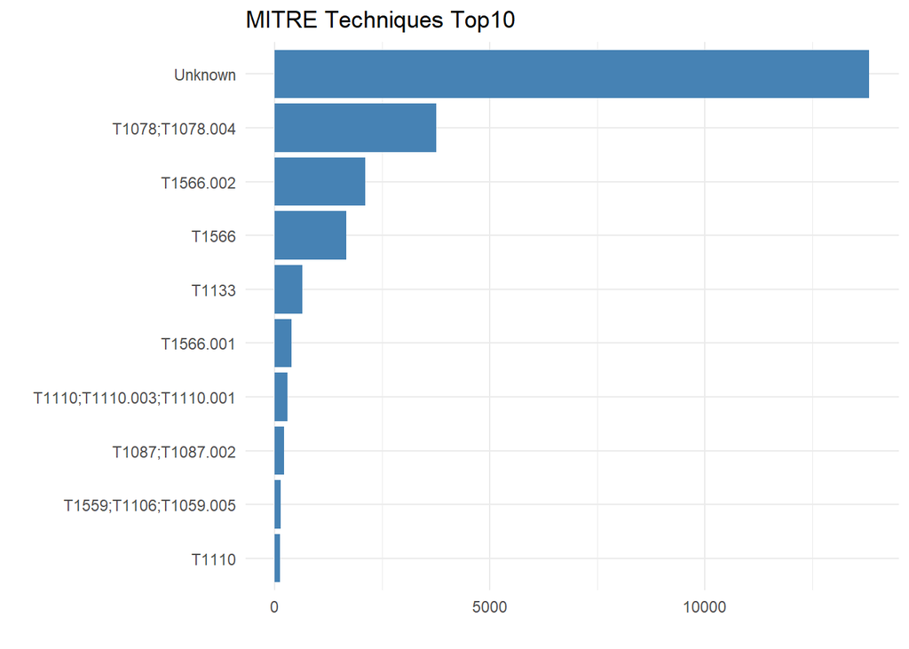

```r
technique_counts <- df %>%
  group_by(MitreTechniques) %>%
  summarise(Count = n())

techniques_ordone <- technique_counts %>%
  arrange(desc(Count))

ggplot(data = head(techniques_ordone, 10),
       aes(y = fct_reorder(MitreTechniques, Count), x = Count)) +
  geom_bar(stat = "identity", fill = "steelblue") +
  labs(
    title = "MITRE Techniques Top10",
    x= " ",
    y  = " "
  ) +
  theme_minimal()
```

**interprétation** :

La majorité des alertes sont associées à «Unknown» , ce qui signifie qu’on n’est pas capable de répérer la source et les méthodes de plusiers attaques. On devrait renforcer davantage la cibersécurité et former les employés, ou recruter des spécialistes.

Les techniques T1078, T1566, et T1133 sont les plus courantes après “Unknown”, ce qui suggère que ces méthodes sont des vecteurs d’attaque privilégiés.

Certaines attaques combinent plusieurs techniques , ce qui signifie qu’un modèle de détection efficace doit prendre en compte les relations entre ces différentes méthodes .

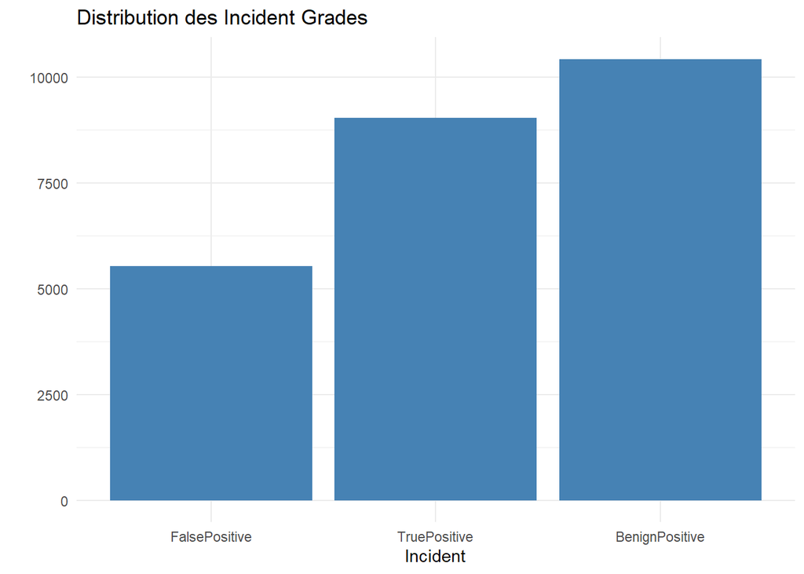

```r
IncidentGrade_count <- df %>%
  group_by(IncidentGrade) %>%
  summarise(Count = n())

ggplot(data = IncidentGrade_count,
       aes(x = fct_reorder(IncidentGrade, Count), y = Count)) +
  geom_bar(stat = "identity", fill = "steelblue") +
  labs(
    title = "Distribution des Incident Grades",
    x = "Incident",
    y = " "
  ) +
  theme_minimal()
```

**Interpretation** : Le nombre élevé de BenignPositive et FalsePositive indique que le système génère beaucoup d’alertes inutiles (bruit).Ce qui est contre productif. Une première recommandation est déjà de rafinner et d’améliorer le système d’alerte pour qu’il capte moin de bruit.

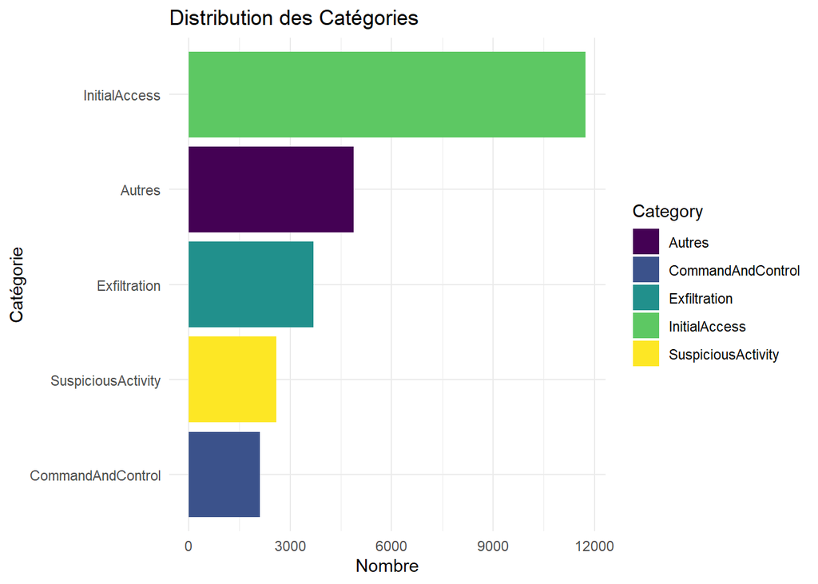

```r
category_counts <- df %>%
  count(Category, name = "Count") %>%
  arrange(desc(Count))

top_4_categories <- category_counts %>%
  head(4)


autres_count <- sum(category_counts$Count) - sum(top_4_categories$Count)

top_5_categories <- top_4_categories %>%
  add_row(Category = "Autres", Count = autres_count)

#ggplot(top_5_categories, aes(x = "", y = Count, fill = fct_reorder(Category, -Count))) +
  #geom_bar(stat = "identity", width = 1) +
  #coord_polar(theta = "y", start = 0) +
  #labs(title = "Distribution des Catégories") +
  #theme_void() +
  #scale_fill_viridis_d()

ggplot(top_5_categories, aes(x = fct_reorder(Category, Count), y = Count, fill = Category)) +
  geom_bar(stat = "identity") +
  coord_flip() +  # Met les barres à l'horizontale
  labs(title = "Distribution des Catégories", x = "Catégorie", y = "Nombre") +
  theme_minimal() +
  scale_fill_viridis_d()
```

**interpretation** :

*Initial Access*est la catégorie la plus fréquente Cela signifie que la majorité des alertes concernent des tentatives d’accès initiales (ex. hameçonnage, exploitation de vulnérabilités).

*Exfiltration*arrive en deuxième position Cela correspond aux tentatives de vol de données en dehors du réseau cible ce qui indique aussi que des attaquants ont réussi à pénétrer les systèmes et tenter d’exfiltrer des informations sensibles.

*Autres* cette catégorie regroupe toutes les autres catégories moins fréquentes.

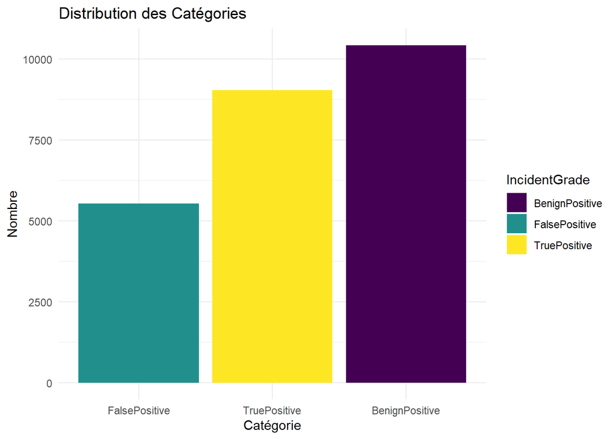

```r
incident_counts <- df %>%
  count(IncidentGrade, name = "Count")

ggplot(incident_counts, aes(x = fct_reorder(IncidentGrade, Count), y = Count, fill = IncidentGrade)) +
  geom_bar(stat = "identity") +
  #coord_flip() +  # Met les barres à l'horizontale
  labs(title = "Distribution des Catégories", x = "Catégorie", y = "Nombre") +
  theme_minimal() +
  scale_fill_viridis_d()
```

**interpretation**

*BenignPositive*(Majoritaire) représente une grande partie du graphique. Ce qui signifie que le système présent capture énormément de fausses alertes.

*TruePositive* (Proportion élevée) indique que le système de détection a bien identifié de véritables incidents qui sont des alertes valides et confirmées comme étant des menaces . Une proportion élevée de TruePositiveest un bon signe car cela signifie que la détection est efficace.

*FalsePositive* (Moins fréquents) ce sont des alertes générées à tort. Une proportion trop élevée de FalsePositive peut poser problème , car cela signifie que l’algorithme génère trop d’alertes inutiles , ce qui peut surcharger les analystes et réduire la confiance dans le système.

**Puisque nous voulons faire une regression logistique pour prédire la variable ‘IncidentGrade’, nous allons modifier cette dernière pour obtenir juste deux classes de la façon suivante :**

BenignPositive –> negatif

FalsePositive –> negatif

TruePositive –> positif

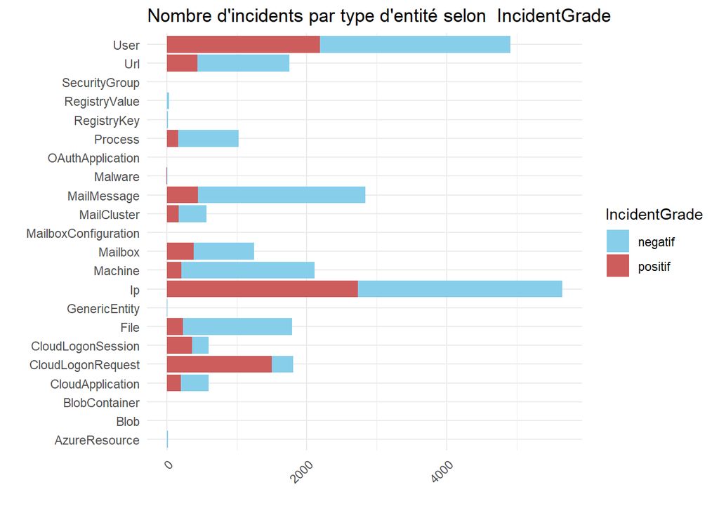

```r
ggplot(df, aes(x = EntityType, fill = IncidentGrade)) +
  geom_bar() +
  labs(
    title = "Nombre d'incidents par type d'entité selon  IncidentGrade",
    x = " ",
    y = " "
  ) +
  theme_minimal() +
  scale_fill_manual(values = c("negatif" ="skyblue" , "positif" ="indianred" ))  +
  theme(axis.text.x = element_text(angle = 45, hjust = 1)) +
  coord_flip()
```

**interpretation**

Les entités les plus affectées sont Ip, Machine, User, etMailMessage,ces entités sont les plus exposées aux incidents de sécurité et nécessairement une surveillance renforcée.

*IncidentGrade* est négatif(bleu) certaines entités ont un grand nombre d’incidents classés comme négatifs ( negatif en bleu) comme Ip, MailMessage, et Machine ce qui peut indiquer quil ya trop de fausses alertes,des règles de détection trop sensibles oubien un filtrage inadéquat des menaces réelles .

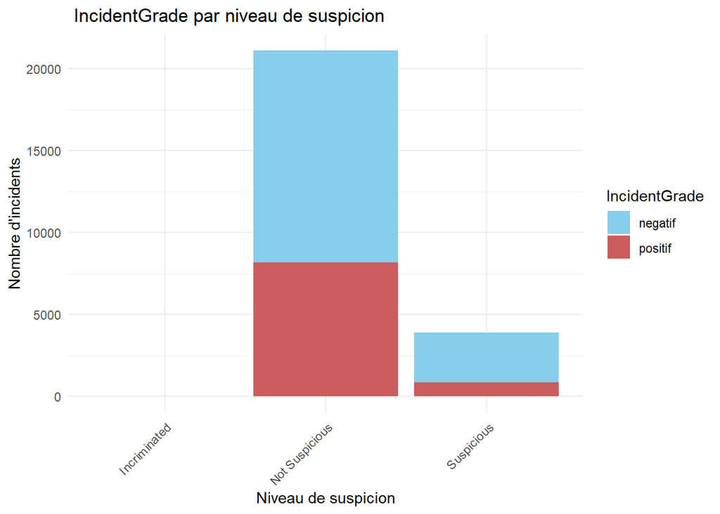

```r
ggplot(df, aes(x = SuspicionLevel, fill = IncidentGrade)) +
  geom_bar() +
  labs(
    title = " IncidentGrade par niveau de suspicion",
    x = "Niveau de suspicion",
    y = "Nombre d'incidents"
  ) +
  theme_minimal() +
  scale_fill_manual(values = c("negatif" ="skyblue" , "positif" ="indianred"))  +
  theme(axis.text.x = element_text(angle = 45, hjust = 1))
```

**interpretation**

La catégorie *Not Suspicious* représente l’écrasante majorité des incidents cela signifie que la plupart des alertes générées ne sont pas considérées comme suspectes. En gros le système de détection identifie beaucoup d’incidents mais les juge non suspects .

La catégorie *“Incriminated”* n’a pas de données visibles dans le graphique, ce qui suggère soit une absence de cas, soit un nombre très faible.

*IncidentGrade* est positif(rouge) : On observe une proportion importante d’incidents positifs dans *Not Suspicious* ce qui signifie que les menaces réelles sont classées comme «non suspectes»

*Suspicious* contient relativement peu d’incidents la plupart des incidents dans cette catégorie sont des incidents négatifs ( negatif) , ce qui signifie que le modèle considère rarement des événements comme véritablement suspects. Cela peut indiquer que les seuils de suspicion sont trop stricts et n’identifient pas assez d’attaques.

Il faut donc analyser les vrais incidents ( positif) dans *Not Suspicious* pour voir s’il ya des modèles d’attaques cachées. Comparer avec d’autres variables ( MitreTechniques, EntityType) pour identifier les entités les plus touchées dans chaque catégorie.

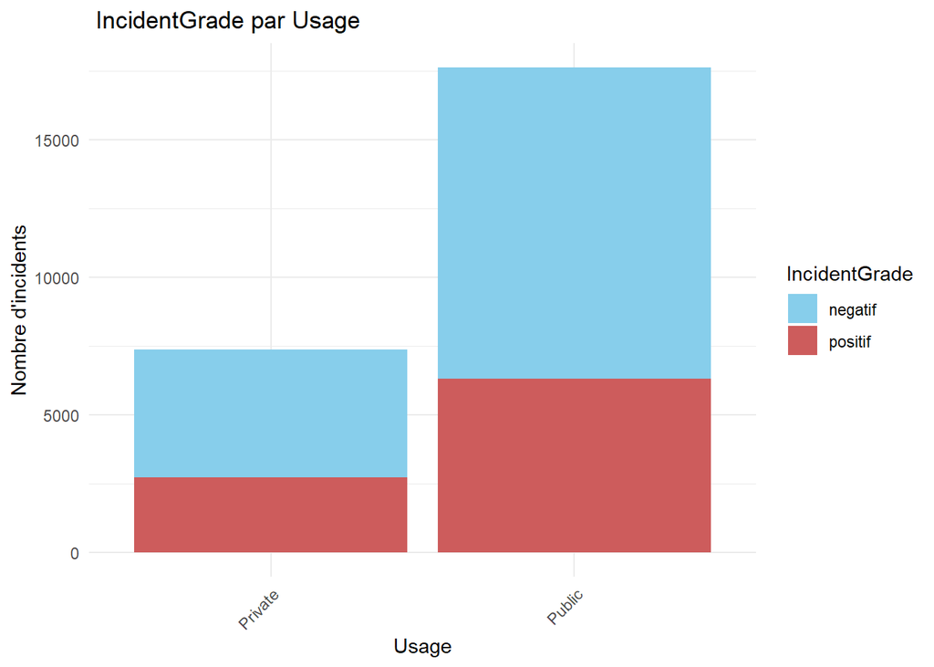

```r
ggplot(df, aes(x = Usage, fill = IncidentGrade)) +
  geom_bar() +
  labs(
    title = " IncidentGrade par Usage",
    x = "Usage",
    y = "Nombre d'incidents"
  ) +
  theme_minimal() +
  scale_fill_manual(values = c("negatif" ="skyblue" , "positif" ="indianred" ))  +
  theme(axis.text.x = element_text(angle = 45, hjust = 1))
```

**interpretation**

Les entités *Public* génèrent un nombre d’incidents nettement plus élevé que les entités Private. Cela signifie que les ressources publiques (ex. serveurs accessibles sur Internet, services cloud publics) sont beaucoup plus ciblées par des activités suspectes ou malveillantes.

*IncidentGrade* est positif(rouge):Le nombre d’incidents *positifs* est plus élevé dans *Public* que dans *Private*.Cela signifie que les attaques réussies sont plus fréquentes sur des ressources publiques car elle sont plus exposés et vulnérables.

Il faut donc analyser les incidents positifs en Public pour identifier les vecteurs d’attaque principaux et evaluer les écarts entre Public et Private afin de voir pourquoi les ressources privées ont-elles moins d’incidents confirmés.

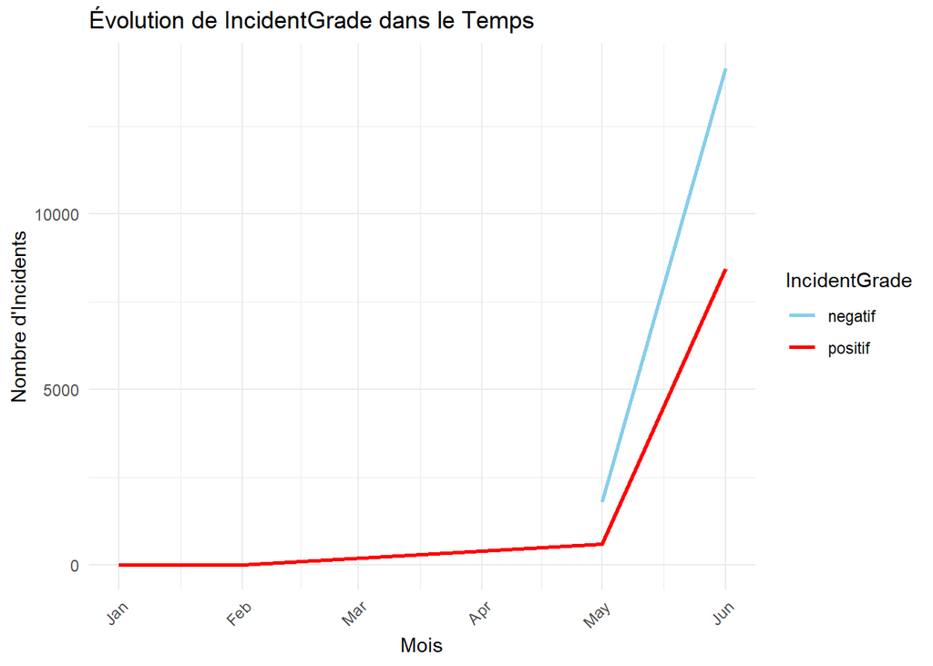

```r
incident_grade_monthly <- df %>%
  mutate(Month = floor_date(Timestamp, "month")) %>%
  group_by(Month, IncidentGrade) %>%
  summarise(Count = n(), .groups = 'drop')

# Graphique de l'évolution des IncidentGrade dans le temps

ggplot(incident_grade_monthly, aes(x = Month, y = Count, color = IncidentGrade)) +
  geom_line(size = 1) +
  labs(
    title = "Évolution de IncidentGrade dans le Temps",
    x = "Mois",
    y = "Nombre d'Incidents",
    color = "IncidentGrade"
  ) +
  theme_minimal() +
  scale_color_manual(values = c("negatif" = "skyblue", "positif" = "red")) +
  theme(axis.text.x = element_text(angle = 45, hjust = 1))
```

**interpretation** : On remarque que les déclarations d’incidents sont stables durant l’hivers. et le système ne capture que les transactions frauduleuse.

C’est en mai et Juin que se dégagent la majorité des signalements. Possible lien avec tous les mouvements qui se déroulent durant l’été ? c’est une question qu’il faudra explorer.

Faisons un zoom sur les fluxtuations pendant le mois de mai

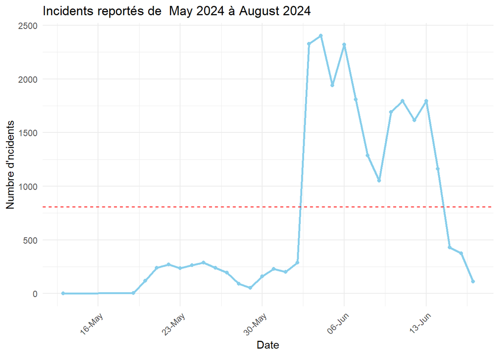

```r
start_date <- as.Date("2024-05-01")
end_date <- as.Date("2024-08-30")

filtered_data <- df %>%
  filter(Timestamp >= start_date & Timestamp <= end_date)

daily_counts <- filtered_data %>%
  group_by(Date = Timestamp) %>%
  summarise(Count = n(), .groups = "drop")

ggplot(daily_counts, aes(x = Date, y = Count)) +
  geom_line(color = "skyblue", size = 1) +
  geom_point(color = "skyblue") +
  labs(
    title = paste("Incidents reportés de ", format(start_date, "%B %Y"), "à", format(end_date, "%B %Y")),
    x = "Date",
    y = "Numbre d'ncidents"
  ) +
  theme_minimal() +
  theme(axis.text.x = element_text(angle = 45, hjust = 1)) +
  scale_x_date(date_breaks = "7 days", date_labels = "%d-%b") +
  geom_hline(yintercept = mean(daily_counts$Count), linetype = "dashed", color = "red")
```

**Interprétation** :

On observe une augmentation brutale autour du 1er juin , où le nombre d’incidents passe de moins de 500 à plus de 1500 en quelques jours du a des activité malveillante.Après le pic début juin, le nombre d’incidents commence à redescendre , avec une apparition notable entre le 6 et le 13 juin.Une tendance clairement baissière après le 13 juin ce qui es du surement a une réponse efficace des équipes de cybersécurité ou une résolution des problèmes détectés début juin. La ligne rouge indique la moyenne du nombre d’incidents sur la période .

Analysons les incidents entre le 1er et le 6 juin afin d’dentifier la cause du pic, vérifiions l’impact des contre-mesures après le 13 juin Ont-elles été efficaces ?

**Un approche serait de limiter notre étude aux incidents se produisant entre le 16 mai et le 13 juin, pour capter le flux de variation et optimiser le modèle. Mais nous n’allons pas le faire dans le cadre de ce travail.**

### 3. Regression logistique

Avant de commencer, on va scinder notre jeu de donnée en un ensemble d’entrainement et un ensemble de test.

```r
set.seed(165)
split <- initial_split(df, prop = 0.8)
df_train <- training(split)
df_test <- testing(split)
```

On va desormais travailler uniquement sur l’ensemble d’entrainement pour batir le modèle.

```r
df_ <- df_train #Je n'ai pas envie de modifier df_train pour l'instant
df_[] <- lapply(df_train, function(x) if(is.factor(x)) as.integer(x) else x)
#head(df_)

df_predicteurs <- list()
for(colonne in colnames(df_)[colnames(df_) != "IncidentGrade"]){
  model <- glm(IncidentGrade ~ get(colonne), data = df_, family = binomial)
  model_summary <- summary(model)
  p_value <- model_summary$coefficients[, 4]
  if ((p_value[2] > 0.0001 & p_value[2] < 0.05)){
# p=0 --> la corresprondance est parfaite donc les variables sont colineaires
#p>0.05 --> la variable n'est pas significative, donc on peut l'enlever
    cat('p-value pour', colonne, '= ', p_value[2], "\n")
    df_predicteurs = c(df_predicteurs, colonne)
  }
}
```

```
## p-value pour Timestamp =  0.005018557
## p-value pour RegistryKey =  0.02718011
## p-value pour RegistryValueName =  0.04827328
## p-value pour RegistryValueData =  0.01957452
## p-value pour Usage =  0.03287417
```

```r
df_predicteurs <- unlist(df_predicteurs)
df_prepare <- df_[, df_predicteurs]
df_prepare$IncidentGrade = df_train$IncidentGrade
#a ce niveau, les donnees sont bien preparees, on peut travailler avec
df_train = df_prepare
```

```r
glm.fits <- glm(IncidentGrade ~ Timestamp + RegistryKey + Usage , data = df_train , family = binomial)
summary(glm.fits)
```

```
##
## Call:
## glm(formula = IncidentGrade ~ Timestamp + RegistryKey + Usage,
##     family = binomial, data = df_train)
##
## Coefficients:
##               Estimate Std. Error z value Pr(>|z|)
## (Intercept) 131.201101  50.503735   2.598  0.00938 **
## Timestamp    -0.006913   0.002537  -2.725  0.00642 **
## RegistryKey   0.304977   0.138120   2.208  0.02724 *
## Usage        -0.071423   0.032140  -2.222  0.02627 *
## ---
## Signif. codes:  0 '***' 0.001 '**' 0.01 '*' 0.05 '.' 0.1 ' ' 1
##
## (Dispersion parameter for binomial family taken to be 1)
##
##     Null deviance: 26184  on 19999  degrees of freedom
## Residual deviance: 26138  on 19996  degrees of freedom
## AIC: 26146
##
## Number of Fisher Scoring iterations: 7
```

**interpretation**:

Les variables Timestamp, RegistryKey et Usage sont statistiquement significatives.

- Intercept (131.201) –> lorsqu’aucune des variables explicatives n’est prise en compte, IncidentGrade a une forte tendance à être considéré comme frauduleux .
- Timestamp = -0.006913 (p = 0.006) –> à mesure que le temps passe, les incident ont moins tendance à être catégorisés comme suspectes. Cet effet est statistiquement significatif.
- RegistryKey = 0.304977 (p = 0.027) –> certaines valeurs de RegistryKey augmentent les chances d’un incident frauduleux par rapport à une catégorie de référence.

Une Piste est de regarder individuellement toutes les clés qui N’ont été utiliséee qu’une seule fois.

```r
Registry_counts <- df %>%
  count(RegistryKey, name = "Count") %>%
  arrange(desc(Count))
t(Registry_counts)%>%
  kable()
```

| RegistryKey | 1631 | 0 | 1 | 2 | 10 | 11 | 22 | 27 | 39 | 50 | 175 | 365 | 513 | 546 | 612 | 647 | 656 | 888 | 1285 |
| --- | --- | --- | --- | --- | --- | --- | --- | --- | --- | --- | --- | --- | --- | --- | --- | --- | --- | --- | --- |
| Count | 24946 | 25 | 13 | 1 | 1 | 1 | 1 | 1 | 1 | 1 | 1 | 1 | 1 | 1 | 1 | 1 | 1 | 1 | 1 |

- Usage (-0.071423) : Cela pourrait signifier que plus une ressource (Usage) est utilisée, moins elle est associée à un incident de type frauduleux.

```r
glm.fits <- glm(IncidentGrade ~ Timestamp + RegistryKey + Usage,
                data = df_train,
                family = binomial)
summary(glm.fits)
```

```
##
## Call:
## glm(formula = IncidentGrade ~ Timestamp + RegistryKey + Usage,
##     family = binomial, data = df_train)
##
## Coefficients:
##               Estimate Std. Error z value Pr(>|z|)
## (Intercept) 131.201101  50.503735   2.598  0.00938 **
## Timestamp    -0.006913   0.002537  -2.725  0.00642 **
## RegistryKey   0.304977   0.138120   2.208  0.02724 *
## Usage        -0.071423   0.032140  -2.222  0.02627 *
## ---
## Signif. codes:  0 '***' 0.001 '**' 0.01 '*' 0.05 '.' 0.1 ' ' 1
##
## (Dispersion parameter for binomial family taken to be 1)
##
##     Null deviance: 26184  on 19999  degrees of freedom
## Residual deviance: 26138  on 19996  degrees of freedom
## AIC: 26146
##
## Number of Fisher Scoring iterations: 7
```

```r
glm.props <- predict(glm.fits, df_train, type =  "response")
glm.pred <- ifelse(glm.props > 0.4, "Frauduleux", "Non Frauduleux")
IncidentGrade_train <- ifelse(df_train$IncidentGrade == 1, "Frauduleux", "Non Frauduleux")
table(glm.pred,IncidentGrade_train)
```

```
##                 IncidentGrade_train
## glm.pred         Frauduleux Non Frauduleux
##   Frauduleux             25             84
##   Non Frauduleux       7216          12675
```

```r
precision <- mean(glm.pred == IncidentGrade_train)
cat("La précision du modèle est : ", round(precision, 2))
```

```
## La précision du modèle est :  0.64
```

```r
df_test$RegistryKey = as.integer(df_test$RegistryKey)
df_test$Usage = as.integer(df_test$Usage)

glm.props_test <- predict(glm.fits, df_test, type =  "response")
glm.pred_test <- ifelse(glm.props_test > 0.4, "Frauduleux", "Non Frauduleux")

IncidentGrade_test <- ifelse(df_test$IncidentGrade == 1, "Frauduleux", "Non Frauduleux")
table(glm.pred_test, IncidentGrade_test)
```

```
##                 IncidentGrade_test
## glm.pred_test    Frauduleux Non Frauduleux
##   Frauduleux              8             19
##   Non Frauduleux       1785           3188
```

```r
precision_test <- mean(glm.pred_test == IncidentGrade_test)
cat("\n Précision du modèle sur les données de test : ", round(precision_test, 2))
```

```
##
##  Précision du modèle sur les données de test :  0.64
```

- Interpretation : le modèle a la même précision de 64% pour les données de test :

## 4 Modèle Batit sur la vrai base de données au complet.

```r
# On selectionne les colonnes utiles

df <- Database[, c("Timestamp", "RegistryKey", "Usage", "IncidentGrade")]
#On prepare les données sous la base de tout ce qui est dejà connu plus haut


df$Timestamp <- as.Date(df$Timestamp, format = "%Y-%m-%d")

df$RegistryKey = as.factor(df$RegistryKey)
df$IncidentGrade = as.factor(df$IncidentGrade)
df$Usage = as.factor(df$Usage)

df <- df %>%
  mutate(
    IncidentGrade = case_when(
      IncidentGrade == "BenignPositive" ~ "negatif",
      IncidentGrade == "FalsePositive" ~ "negatif",
      IncidentGrade == "TruePositive" ~ "positif"
    )
  )
df$IncidentGrade <- ifelse(df$IncidentGrade == "positif", 1, 0)



# La suite du code ne compile pas il nous faudrait un super calculateur.

#message d'erreur : Notre ordinateur n'a pas assez de memoire pour allouer 30.8 GO

# On effectue maintenant le test

#glm.fits <- glm(IncidentGrade ~ Timestamp + RegistryKey + Usage,
          #      data = df,
           #     family = binomial)
#summary(glm.fits)
#glm.props <- predict(glm.fits, df, type =  "response")
#glm.pred <- ifelse(glm.props > 0.4, "Frauduleux", "Non Frauduleux")
#IncidentGrade <- ifelse(df$IncidentGrade == 1, "Frauduleux", "Non Frauduleux")
#table(glm.pred,IncidentGrade)
#precision <- mean(glm.pred == IncidentGrade)
#cat("La précision du modèle est : ", round(precision, 2))
```

## Quelques recommandations :

1. Engager d’avantages des spécialistes en cibersécurité et former le personnel ;
2. Mettre sur pied des publicités de sensibilisation ;
3. Mettre une surveillance accrue sur les ressources moins utilisées ;
4. Renforcer la surveillance et les mesures de sécurité en été ;
5. Regarder particulièrement les opérations qui se sont effectuées avec les clés suivantes, dans l’ordre de priorité descandante.

```r
Registry_counts <- Database %>%
  count(RegistryKey, name = "Count") %>%
  filter(Count <= 2)%>%
  arrange(Count)

transactions_suspectes <- Database %>%
  filter(RegistryKey %in% Registry_counts$RegistryKey)

transactions_suspectes %>%
  select(RegistryKey,AlertTitle, Category,LastVerdict,Usage)%>%
  head(25)%>%
  kable()
```

| RegistryKey | AlertTitle | Category | LastVerdict | Usage |
| --- | --- | --- | --- | --- |
| 455 | 360 | Persistence | Suspicious | Private |
| 97 | 751 | DefenseEvasion | Suspicious | Private |
| 984 | 839 | Persistence | Suspicious | Public |
| 433 | 264 | Persistence | Suspicious | Public |
| 1023 | 264 | Persistence | Suspicious | Public |
| 490 | 360 | Persistence | Suspicious | Public |
| 274 | 27918 | DefenseEvasion |  | Public |
| 609 | 360 | Persistence | Suspicious | Public |
| 1533 | 839 | Persistence | Suspicious | Public |
| 1340 | 360 | Persistence | Suspicious | Public |
| 1386 | 360 | Persistence | Suspicious | Private |
| 1606 | 11886 | Execution |  | Private |
| 970 | 839 | Persistence | Suspicious | Public |
| 355 | 2886 | Persistence | Suspicious | Public |
| 993 | 839 | Persistence | Suspicious | Public |
| 1348 | 360 | Persistence | Suspicious | Public |
| 936 | 13945 | Malware | Malicious | Private |
| 930 | 4567 | Malware | Malicious | Public |
| 1546 | 839 | Persistence | Suspicious | Public |
| 617 | 360 | Persistence | Suspicious | Public |
| 456 | 360 | Persistence | Suspicious | Public |
| 1624 | 344 | Collection |  | Private |
| 557 | 264 | Persistence | Suspicious | Public |
| 267 | 360 | Persistence | Suspicious | Public |
| 537 | 264 | Persistence | Suspicious | Private |

```r
#La totalité sera fournies en fichier annexe nommé opérations suspectes
```